# Data Analytics for Finance

BM17FI · Rotterdam School of Management

[figure not shown]

ASSIGNMENT 05

## Setup

Run these cells to prepare your environment.

```
✅ Environment cleared and ready.
```

```
✅ Required packages installed.
```

```
/Users/casparm4/Github/rsm-data-analytics-in-finance-private/private/assignment
> s/05-assignment
📁 Base directory: /Users/casparm4/Github/rsm-data-analytics-in-finance-private
> /private/assignments/05-assignment
📁 Raw data folder: /Users/casparm4/Github/rsm-data-analytics-in-finance-privat
> e/private/assignments/05-assignment/data/raw
📁 Processed data folder: /Users/casparm4/Github/rsm-data-analytics-in-finance-
> private/private/assignments/05-assignment/data/processed
📁 Output directory: /Users/casparm4/Github/rsm-data-analytics-in-finance-priva
> te/private/assignments/05-assignment/output
📁 Tables folder: /Users/casparm4/Github/rsm-data-analytics-in-finance-private/
> private/assignments/05-assignment/output/tables
📁 Figures folder: /Users/casparm4/Github/rsm-data-analytics-in-finance-private
> /private/assignments/05-assignment/output/figures
```

## Learning Objectives

By completing this assignment, you will:

1. **Understand event study methodology** and its role in measuring stock market reactions
2. **Define estimation and event windows** appropriate for the research question
3. **Estimate the Market Model** for expected returns using country-specific indices
4. **Estimate the Fama-French 3-Factor Model** as a more sophisticated benchmark
5. **Calculate abnormal and cumulative abnormal returns** (CARs)
6. **Compare results across different benchmark models** to assess robustness
7. **Conduct cross-sectional tests** to explain variation in CARs
8. **Create event study visualizations** with confidence bands

## Research Question

> *"What was the stock market reaction to the Dieselgate scandal announcement, and does the choice of benchmark model affect our conclusions?"*

On **September 18, 2015**, the U.S. Environmental Protection Agency (EPA) issued a Notice of Violation to Volkswagen for installing "defeat devices" in diesel vehicles to cheat emissions tests. This assignment measures the stock price impact of this announcement on German automakers compared to non-German peers.

You will estimate abnormal returns using two different benchmark models and compare whether your conclusions are robust to this methodological choice.

ℹ️ Background: Event Study Methodology

An **event study** measures the stock price reaction to a specific event (e.g., earnings announcement, scandal, policy change). The key insight is comparing *actual* returns to *expected* returns:  
**Abnormal Return (AR)** = Actual Return − Expected Return  
The methodology involves two windows:

- **Estimation Window**: A "normal" period before the event used to estimate the expected return model
- **Event Window**: The period around the event where we measure abnormal returns

The **Cumulative Abnormal Return (CAR)** sums abnormal returns over the event window to capture the total price impact.

ℹ️ Background: Benchmark Models

We will compare two models for expected returns:  
**1. Market Model**: A simple single-factor model  
`Ri,t = αi + βi × Rm,t + εi,t`  
Uses the firm's home country market index (e.g., DAX for German firms, Nikkei for Japanese firms).  
**2. Fama-French 3-Factor Model**: Adds size and value factors  
`Ri,t − Rf,t = αi + βmkt(Rm,t − Rf,t) + βsmbSMBt + βhmlHMLt + εi,t`  
Controls for systematic differences in firm size (SMB) and value characteristics (HML).  
**Why compare?** If results are similar across models, our findings are more robust. If they differ, model choice matters and we need to understand why.

📝 Tasks Overview

In this assignment, you will:

1. Load and examine the daily stock price data
2. Clean the sample by dropping VW Group subsidiaries
3. Define estimation and event windows using trading days
4. Estimate the Market Model for each firm
5. Estimate the Fama-French 3-Factor Model for each firm
6. Calculate expected and abnormal returns
7. Calculate Cumulative Abnormal Returns (CAR[0,+5])
8. Compare results across the two models
9. Create event study visualizations
10. Conduct cross-sectional analysis of CARs
11. Perform statistical tests
12. Interpret your findings

## Section 1: Load and Examine Data

In this section, you will load the daily stock price data and explore its structure.

### Task 1.1: Load the Dataset

[figure not shown]

Stata Tip

Use `use "$raw/filename.dta", clear` to load a Stata dataset.

```
✅ Dataset loaded successfully
```

### Task 1.2: Examine the Data Structure

Use `describe` to see all variables, then use `summarize` to check the date range and returns. Use `distinct` to count the number of unique firms.

```
Contains data from /Users/casparm4/Github/rsm-data-analytics-in-finance-private
> /private/assignments/05-assignment/data/raw/auto_firms_daily_eventstudy.dta
 Observations:        63,423
    Variables:            24                  13 Jan 2026 12:05
-------------------------------------------------------------------------------
Variable      Storage   Display    Value
    name         type    format    label      Variable label
-------------------------------------------------------------------------------
gvkey           str6    %-9s
conm            str28   %-9s
sic             str4    %-9s
fic             str3    %-9s
german          long    %12.0g
date            double  %td
index           double  %10.0g
index_name      str35   %-9s
mkt_rf          double  %10.0g
smb             double  %10.0g
hml             double  %10.0g
rf              double  %10.0g
prccd           double  %10.0g
ajexdi          double  %10.0g
ret             double  %10.0g
at              double  %10.0g
sale            double  %10.0g
log_at          double  %10.0g
leverage        double  %10.0g
roa             double  %10.0g
debt_equity     double  %10.0g
roe             double  %10.0g
margin          double  %10.0g
cash_ratio      double  %10.0g
-------------------------------------------------------------------------------
Sorted by:

    Variable |        Obs        Mean    Std. dev.       Min        Max
-------------+---------------------------------------------------------
        date |     63,423     20271.4    316.4475      19724      20818
         ret |     53,567    .0004159    .0309347  -2.324716   1.607794

```

[output cut: 10 more lines]

```
        DEU |      5,481        8.64       34.57
        FRA |        783        1.23       35.80
        GBR |      1,566        2.47       38.27
        HKG |        783        1.23       39.51
        IDN |        783        1.23       40.74
        IND |      8,613       13.58       54.32
        ITA |        783        1.23       55.56
        JPN |     10,179       16.05       71.60
        KOR |      3,132        4.94       76.54
        MYS |      4,698        7.41       83.95
        NLD |      1,566        2.47       86.42
        PAK |      5,481        8.64       95.06
        SWE |      3,132        4.94      100.00
------------+-----------------------------------
      Total |     63,423      100.00
```

### Task 1.3: Set Panel Structure

Declare the data as a panel using `xtset`. Since `gvkey` is a string variable, you first need to create a numeric identifier.

[figure not shown]

Stata Tip

- `encode gvkey, gen(gvkey_num)` — Convert string to numeric
- `xtset gvkey_num date` — Declare panel structure

```
Panel variable: gvkey_num (strongly balanced)
 Time variable: date, 01jan2014 to 30dec2016, but with gaps
         Delta: 1 day

gvkey_num:  1, 2, ..., 81                                    n =         81
    date:  01jan2014, 02jan2014, ..., 30dec2016              T =        783
           Delta(date) = 1 day
           Span(date)  = 1095 periods
           (gvkey_num*date uniquely identifies each observation)

Distribution of T_i:   min      5%     25%       50%       75%     95%     max
                       783     783     783       783       783     783     783

     Freq.  Percent    Cum. |  Pattern*
 ---------------------------+--------------------------------------------------
> ----------------------------------------------------
       81    100.00  100.00 |  887979788797978879797887979788797978879797887979
> 7887979788797978879797887979788797978879797887979785
 ---------------------------+--------------------------------------------------
> ----------------------------------------------------
       81    100.00         |  XXXXXXXXXXXXXXXXXXXXXXXXXXXXXXXXXXXXXXXXXXXXXXXX
> XXXXXXXXXXXXXXXXXXXXXXXXXXXXXXXXXXXXXXXXXXXXXXXXXXXX
 ------------------------------------------------------------------------------
> ----------------------------------------------------
 *Each column represents 11 periods.
```

```
✅ Section 1 tests passed
```

## Section 2: Sample Construction

Before analysis, we need to clean the sample by removing firms that are part of the Volkswagen Group. These subsidiaries and holding companies are mechanically linked to VW and would confound our analysis.

ℹ️ Background: Sample Construction

The following firms should be **dropped** from the sample:

- **AUDI AG** (gvkey: 101120) — VW subsidiary
- **PORSCHE AUTOMOBIL HOLDING SE** (gvkey: 102187) — VW Group holding company
- **SCANIA AB** (gvkey: 062557) — VW subsidiary (commercial vehicles)
- **MAN SE** (gvkey: 100042) — VW subsidiary (trucks/buses)

**Why drop these firms?**

1. **Avoid double-counting**: Subsidiaries' stock prices are mechanically linked to VW's scandal
2. **Clean identification**: We want to compare independent German automakers (VW, BMW, Mercedes-Benz) to non-German peers
3. **Economic interpretation**: Holding companies don't represent separate business operations

### Task 2.1: Identify Treatment and Control Groups

First, examine which firms are in the dataset and how they are classified by the `german` indicator.

```
                      |        german
                 conm |         0          1 |     Total
----------------------+----------------------+----------
ANHUI ANKAI AUTOMOB.. |       783          0 |       783
ANHUI JIANGHUAI AUT.. |       783          0 |       783
    ASHOK LEYLAND LTD |       783          0 |       783
ASTON MARTIN LAGOND.. |       783          0 |       783
        ATUL AUTO LTD |       783          0 |       783
              AUDI AG |         0        783 |       783
          AUTECH CORP |       783          0 |       783
AVIC SHENYANG AIRCR.. |       783          0 |       783
BAIC BLUEPARK NEW E.. |       783          0 |       783
  BAIC MOTOR CORP LTD |       783          0 |       783
BAYERISCHE MOTOREN .. |         0        783 |       783
      BYD COMPANY LTD |       783          0 |       783
CHERY AUTOMOBILE CO.. |       783          0 |       783
CHIN HIN GROUP PROP.. |       783          0 |       783
CHINA EVERGRANDE NE.. |       783          0 |       783
CHONG QING CHANGAN .. |       783          0 |       783
CHONGQING DIMA INDU.. |       783          0 |       783
        CME GROUP BHD |       783          0 |       783
DEWAN FAROOQUE MOTO.. |       783          0 |       783
DONGFENG MOTOR GROU.. |       783          0 |       783
     DRB HICOM BERHAD |       783          0 |       783
        EICHER MOTORS |       783          0 |       783
           FERRARI NV |       783          0 |       783
        FLEETWOOD LTD |       783          0 |       783
     FORCE MOTORS LTD |       783          0 |       783
GHANDHARA AUTOMOBIL.. |       783          0 |       783
  GREAT WALL MOTOR CO |       783          0 |       783
GUANGDONG LVTONG NE.. |       783          0 |       783
GUANGZHOU AUTOMOBIL.. |       783          0 |       783
         H-ONE CO LTD |       783          0 |       783
HAIMA AUTOMOBILE CO.. |       783          0 |       783
 HINDUSTAN MOTORS LTD |       783          0 |       783
      HINO MOTORS LTD |       783          0 |       783
   HINOPAK MOTORS LTD |       783          0 |       783
 HONDA ATLAS CARS LTD |       783          0 |       783
   HONDA MOTOR CO LTD |       783          0 |       783
               HWA AG |         0        783 |       783
```

[output cut: 44 more lines]

```
----------------------+----------------------+----------
                Total |    57,942      5,481 |    63,423
German firms in sample:

                        conm |      Freq.     Percent        Cum.
-----------------------------+-----------------------------------
                     AUDI AG |        783       14.29       14.29
BAYERISCHE MOTOREN WERKE AKT |        783       14.29       28.57
                      HWA AG |        783       14.29       42.86
                      MAN SE |        783       14.29       57.14
      MERCEDES BENZ GROUP AG |        783       14.29       71.43
PORSCHE AUTOMOBIL HOLDING SE |        783       14.29       85.71
               VOLKSWAGEN AG |        783       14.29      100.00
-----------------------------+-----------------------------------
                       Total |      5,481      100.00
```

### Task 2.2: Drop VW Group Subsidiaries

Drop the four VW Group firms (AUDI, PORSCHE AUTOMOBIL HOLDING, SCANIA, MAN) using their gvkey identifiers.

[figure not shown]

Stata Tip

Use `drop if inlist(gvkey, "101120", "102187", "062557", "100042")` to remove multiple firms at once.

```
(3,132 observations deleted)
✅ VW Group subsidiaries dropped

Remaining German firms:

                        conm |      Freq.     Percent        Cum.
-----------------------------+-----------------------------------
BAYERISCHE MOTOREN WERKE AKT |        783       25.00       25.00
                      HWA AG |        783       25.00       50.00
      MERCEDES BENZ GROUP AG |        783       25.00       75.00
               VOLKSWAGEN AG |        783       25.00      100.00
-----------------------------+-----------------------------------
                       Total |      3,132      100.00

       |        Observations
       |      total   distinct
-------+----------------------
 gvkey |      60291         77
```

```
✅ Section 2 tests passed
```

## Section 3: Define Event Windows

Now we define the key time periods for the event study: the **estimation window** (to estimate the expected return model) and the **event window** (to measure abnormal returns).

ℹ️ Background: Event Study Windows

**Event Date (t = 0)**: September 18, 2015 — EPA Notice of Violation  
**Estimation Window**: t = -120 to t = -30 (trading days)

- 91 trading days of "normal" returns
- Used to estimate α and β for expected return models
- Gap of 30 days before event prevents contamination

**Event Window**: t = 0 to t = +5 (trading days)

- 6 trading days (one week) after the announcement
- CAR[0,+5] captures the cumulative price impact

### Task 3.1: Create Relative Trading Day Variable

Create a variable `relday` that measures the number of **trading days** relative to the event date. This is more accurate than calendar days because markets are closed on weekends and holidays.

The approach:

1. Create a running trading day counter within each firm
2. Find the trading day number for September 18, 2015
3. Calculate `relday` = current trading day − event trading day

[figure not shown]

Stata Tip

- `td(18sep2015)` — Creates a Stata date for September 18, 2015
- `by gvkey_num: gen trading_day = _n` — Creates a running counter within each firm
- `egen ... = max(...)` — Expands a value to all observations within a group

```
(60,214 missing values generated)
VW stock around event date:

  +---------------------------------+
  |      date   relday          ret |
  |---------------------------------|
  | 16sep2015       -2    .00388815 |
  | 17sep2015       -1   -.00059719 |
  | 18sep2015        0   -.03681024 |
  | 21sep2015        1   -.18797743 |
  | 22sep2015        2    -.1842681 |
  |---------------------------------|
  | 23sep2015        3    .06695242 |
  | 24sep2015        4            0 |
  | 25sep2015        5   -.02857947 |
  +---------------------------------+
```

### Task 3.2: Create Window Indicator Variables

Create two indicator variables:

- `estimation_window`: equals 1 if `relday` is between -120 and -30
- `event_window`: equals 1 if `relday` is between 0 and +5

```
Observations in each window:

estimation_ |
     window |      Freq.     Percent        Cum.
------------+-----------------------------------
          0 |     53,284       88.38       88.38
          1 |      7,007       11.62      100.00
------------+-----------------------------------
      Total |     60,291      100.00

event_windo |
          w |      Freq.     Percent        Cum.
------------+-----------------------------------
          0 |     59,829       99.23       99.23
          1 |        462        0.77      100.00
------------+-----------------------------------
      Total |     60,291      100.00

Trading days per firm in estimation window:

Summary for variables: est_days
Group variable: conm

            conm |      Mean
-----------------+----------
ANHUI ANKAI AUTO |        91
ANHUI JIANGHUAI  |        91
ASHOK LEYLAND LT |        91
ASTON MARTIN LAG |        91
   ATUL AUTO LTD |        91
     AUTECH CORP |        91
AVIC SHENYANG AI |        91
BAIC BLUEPARK NE |        91
BAIC MOTOR CORP  |        91
BAYERISCHE MOTOR |        91
 BYD COMPANY LTD |        91
CHERY AUTOMOBILE |        91
CHIN HIN GROUP P |        91
CHINA EVERGRANDE |        91
CHONG QING CHANG |        91
```

[output cut: 48 more lines]

```
SERES GROUP CO L |        91
SML MAHINDRA LTD |        91
   STELLANTIS NV |        91
     SUBARU CORP |        91
SUZUKI MOTOR CO  |        91
TAN CHONG MOTOR  |        91
TATA MOTORS PASS |        91
TOYOTA MOTOR COR |        91
UMW HOLDINGS BHD |        91
   VOLKSWAGEN AG |        91
        VOLVO AB |        91
VOLVO CAR AB PUB |        91
WILLIAMS GRAND P |        91
YANGZHOU YAXING  |        91
----------------------------
```

```
✅ Section 3 tests passed
```

## Section 4: Market Model Estimation

The Market Model relates a stock's return to the overall market return. We estimate this relationship during the estimation window, then use it to predict expected returns during the event window.

ℹ️ Background: The Market Model

The **Market Model** is:  
`Ri,t = αi + βi × Rm,t + εi,t`  
Where:

- **α (alpha)**: Firm-specific return not explained by the market
- **β (beta)**: Sensitivity to market movements (β > 1 means more volatile than market)
- **R<sub>m,t</sub>**: Market return (we use each firm's home country index)

We estimate α and β using the **estimation window**, then use these to calculate expected returns during the event window.

### Task 4.1: Generate Market Return from Index

The dataset contains `index`, which is the level of each firm's home country market index (e.g., MSCI Germany, MSCI Japan, etc.). Calculate the market return as the log change in the index level. Drop any missing values for `mkt_ret`.

[figure not shown]

Stata Tip

Use `by gvkey_num: gen mkt_ret = ln(index / index[_n-1])` to calculate log returns within each firm's time series.

```
(12,089 missing values generated)
(12,089 observations deleted)
Market return summary (estimation window):

    Variable |        Obs        Mean    Std. dev.       Min        Max
-------------+---------------------------------------------------------
     mkt_ret |      5,621    .0000434    .0114619  -.0547831   .0513839

Index names by country:

                      |    fic
           index_name |       JPN |     Total
----------------------+-----------+----------
MSCI - Japan Index .. |       100 |       100
----------------------+-----------+----------
                Total |       100 |       100
```

### Task 4.2: Estimate Market Model for Each Firm

Now estimate the market model (regress `ret` on `mkt_ret`) for each firm using only the **estimation window**. Store the α (alpha) and β (beta) coefficients for each firm.

[figure not shown]

Stata Tip

- `levelsof gvkey_num, local(firms)` — Get list of unique firm IDs
- `foreach f of local firms { ... }` — Loop over firms
- `_b[_cons]` — Access the intercept (α) after regression
- `_b[mkt_ret]` — Access the slope coefficient (β)

```
(48,202 missing values generated)
(48,202 missing values generated)
1 2 3 4 5 6 7 8 10 12 13 14 15 17 18 19 20 22 23 24 25 26 27 28 29 30 31 32 33
> 34 35 36 37 38 39 40 41 42 43 44 45 46 47 48 49 50 51 52 53 54 55 56 57 58 59
>  60 61 62 63 64 65 66 67 68 69 70 71 72 73 74 75 76 77 78 79 80 81
Market Model Coefficients by Firm:

Summary statistics: Mean
Group variable: conm

            conm |  alpha_mm   beta_mm
-----------------+--------------------
ANHUI ANKAI AUTO |    0.0019    1.8481
ANHUI JIANGHUAI  |   -0.0016    0.9186
ASHOK LEYLAND LT |    0.0008    0.1152
ASTON MARTIN LAG |         .         .
   ATUL AUTO LTD |   -0.0036    0.5989
     AUTECH CORP |   -0.0006    0.1079
AVIC SHENYANG AI |    0.0027    1.5474
BAIC BLUEPARK NE |         .         .
BAIC MOTOR CORP  |   -0.0047    0.9653
BAYERISCHE MOTOR |   -0.0015    1.0204
 BYD COMPANY LTD |   -0.0017    2.1552
CHERY AUTOMOBILE |         .         .
CHIN HIN GROUP P |   -0.0018    0.1692
CHINA EVERGRANDE |    0.0041    2.0012
CHONG QING CHANG |   -0.0011    2.4980
CHONGQING DIMA I |   -0.0001    0.5394
   CME GROUP BHD |    0.0031    0.0949
DEWAN FAROOQUE M |    0.0125    0.7234
DONGFENG MOTOR G |   -0.0045    0.8540
DRB HICOM BERHAD |   -0.0030    0.2356
   EICHER MOTORS |    0.0030    0.0646
      FERRARI NV |         .         .
   FLEETWOOD LTD |    0.0051   -0.5701
FORCE MOTORS LTD |         .         .
GHANDHARA AUTOMO |    0.0109    0.1370
GREAT WALL MOTOR |   -0.0085    0.8371
GUANGDONG LVTONG |         .         .
GUANGZHOU AUTOMO |   -0.0036    1.0292
```

[output cut: 35 more lines]

```
SERES GROUP CO L |         .         .
SML MAHINDRA LTD |    0.0005   -0.1846
   STELLANTIS NV |         .         .
     SUBARU CORP |    0.0016    1.0561
SUZUKI MOTOR CO  |    0.0023    1.2240
TAN CHONG MOTOR  |    0.0011    0.0298
TATA MOTORS PASS |   -0.0040    0.0173
TOYOTA MOTOR COR |   -0.0006    0.9390
UMW HOLDINGS BHD |         .         .
   VOLKSWAGEN AG |   -0.0020    0.9907
        VOLVO AB |         .         .
VOLVO CAR AB PUB |         .         .
WILLIAMS GRAND P |    0.0015    0.0788
YANGZHOU YAXING  |   -0.0053    2.0123
--------------------------------------
```

```
✅ Section 4 tests passed
```

## Section 5: Fama-French 3-Factor Model

The Fama-French 3-Factor Model extends the Market Model by adding size (SMB) and value (HML) factors. This can provide more accurate expected returns by controlling for systematic differences in firm characteristics.

ℹ️ Background: Fama-French 3-Factor Model

The **Fama-French 3-Factor Model** is:  
`Ri,t − Rf,t = αi + βmkt(Rm,t − Rf,t) + βsmbSMBt + βhmlHMLt + εi,t`  
Additional factors:

- **SMB (Small Minus Big)**: Return of small stocks minus large stocks — captures size effect
- **HML (High Minus Low)**: Return of value stocks minus growth stocks — captures value effect
- **R<sub>f</sub>**: Risk-free rate (we use European factors from Kenneth French's website)

**Why use FF3?** If automakers have different size or value characteristics than the market average, the Market Model might mis-estimate expected returns. FF3 controls for this.

### Task 5.1: Generate Excess Returns

For the Fama-French model, we work with excess returns (returns above the risk-free rate). Create a variable `ret_rf` that equals the stock return minus the risk-free rate.

```
(7,250 missing values generated)
Risk-free rate and excess return summary:

    Variable |        Obs        Mean    Std. dev.       Min        Max
-------------+---------------------------------------------------------
          rf |      5,621           0           0          0          0
         ret |      4,719    .0002893    .0289908  -.1658638   .3342607
      ret_rf |      4,719    .0002893    .0289908  -.1658638   .3342607
```

### Task 5.2: Estimate FF3 Model for Each Firm

Estimate the Fama-French 3-Factor model for each firm using the estimation window. Regress excess returns (`ret_rf`) on the three factors: `mkt_rf`, `smb`, and `hml`. Store all four coefficients (α, β_mkt, β_smb, β_hml) for each firm.

```
(48,202 missing values generated)
(48,202 missing values generated)
(48,202 missing values generated)
(48,202 missing values generated)
1 2 3 4 5 6 7 8 10 12 13 14 15 17 18 19 20 22 23 24 25 26 27 28 29 30 31 32 33
> 34 35 36 37 38 39 40 41 42 43 44 45 46 47 48 49 50 51 52 53 54 55 56 57 58 59
>  60 61 62 63 64 65 66 67 68 69 70 71 72 73 74 75 76 77 78 79 80 81
Fama-French 3-Factor Model Coefficients by Firm:

Summary statistics: Mean
Group variable: conm

            conm |  alpha_ff  beta_m~f  beta_s~f  beta_h~f
-----------------+----------------------------------------
ANHUI ANKAI AUTO |    0.0005    0.0154    0.0118   -0.0171
ANHUI JIANGHUAI  |   -0.0015   -0.0035    0.0078   -0.0068
ASHOK LEYLAND LT |    0.0012   -0.0026   -0.0094   -0.0107
ASTON MARTIN LAG |         .         .         .         .
   ATUL AUTO LTD |   -0.0049    0.0043    0.0061   -0.0214
     AUTECH CORP |   -0.0007   -0.0010   -0.0013   -0.0022
AVIC SHENYANG AI |    0.0019    0.0038    0.0093   -0.0297
BAIC BLUEPARK NE |         .         .         .         .
BAIC MOTOR CORP  |   -0.0060    0.0109    0.0104   -0.0200
BAYERISCHE MOTOR |   -0.0021    0.0032   -0.0184   -0.0093
 BYD COMPANY LTD |   -0.0038    0.0325    0.0379   -0.0201
CHERY AUTOMOBILE |         .         .         .         .
CHIN HIN GROUP P |   -0.0015   -0.0051   -0.0068   -0.0029
CHINA EVERGRANDE |    0.0054    0.0158   -0.0076   -0.0156
CHONG QING CHANG |   -0.0060    0.0180    0.0209   -0.0205
CHONGQING DIMA I |   -0.0008    0.0078    0.0062   -0.0029
   CME GROUP BHD |    0.0016    0.0057    0.0221    0.0101
DEWAN FAROOQUE M |    0.0141   -0.0005   -0.0031    0.0060
DONGFENG MOTOR G |   -0.0048    0.0042    0.0022   -0.0130
DRB HICOM BERHAD |   -0.0043    0.0050    0.0071   -0.0053
   EICHER MOTORS |    0.0019    0.0074    0.0117   -0.0008
      FERRARI NV |         .         .         .         .
   FLEETWOOD LTD |    0.0056   -0.0039   -0.0003   -0.0007
FORCE MOTORS LTD |         .         .         .         .
GHANDHARA AUTOMO |    0.0105    0.0054    0.0038   -0.0049
GREAT WALL MOTOR |   -0.0103    0.0099    0.0187   -0.0114
```

[output cut: 37 more lines]

```
SERES GROUP CO L |         .         .         .         .
SML MAHINDRA LTD |   -0.0001   -0.0009    0.0066   -0.0266
   STELLANTIS NV |         .         .         .         .
     SUBARU CORP |    0.0023    0.0033    0.0019   -0.0045
SUZUKI MOTOR CO  |    0.0025    0.0036    0.0141   -0.0054
TAN CHONG MOTOR  |    0.0007    0.0011    0.0052   -0.0035
TATA MOTORS PASS |   -0.0059    0.0084    0.0186   -0.0200
TOYOTA MOTOR COR |   -0.0002    0.0023    0.0072   -0.0081
UMW HOLDINGS BHD |         .         .         .         .
   VOLKSWAGEN AG |   -0.0023    0.0015   -0.0187   -0.0079
        VOLVO AB |         .         .         .         .
VOLVO CAR AB PUB |         .         .         .         .
WILLIAMS GRAND P |    0.0013    0.0011    0.0004   -0.0050
YANGZHOU YAXING  |   -0.0072    0.0177    0.0229   -0.0104
----------------------------------------------------------
```

```
✅ Section 5 tests passed
```

## Section 6: Calculate Expected and Abnormal Returns

Now that we have estimated both models, we can calculate expected returns and abnormal returns. The abnormal return is the difference between what a stock actually returned and what we expected based on market conditions.

### Task 6.1: Calculate Expected Returns

Using the estimated coefficients, calculate expected returns for both models:

**Market Model**: E[R] = α + β × R_m

**FF3 Model**: E[R] = r_f + α + β_mkt × (R_m − r_f) + β_smb × SMB + β_hml × HML

```
(7,512 missing values generated)
(7,512 missing values generated)
Expected returns summary (event window):

    Variable |        Obs        Mean    Std. dev.       Min        Max
-------------+---------------------------------------------------------
expected_r~m |        325   -.0044743    .0137093  -.0656938   .0330985
expected_r~f |        325   -.0003444    .0136002  -.0611045   .0543933
         ret |        325   -.0033328    .0258564  -.1842681   .0953802
```

### Task 6.2: Calculate Abnormal Returns

Calculate the abnormal return (AR) as the difference between actual and expected returns for both models. As a sanity check, verify that abnormal returns are approximately zero on average during the estimation window.

```
(7,792 missing values generated)
(7,792 missing values generated)
Abnormal returns in estimation window (should be ~0):

    Variable |        Obs        Mean    Std. dev.       Min        Max
-------------+---------------------------------------------------------
       ar_mm |      4,719    1.72e-11    .0262934  -.1791726    .244686
       ar_ff |      4,719   -2.02e-11    .0278926  -.1797156   .2971995

Abnormal returns in event window:

    Variable |        Obs        Mean    Std. dev.       Min        Max
-------------+---------------------------------------------------------
       ar_mm |        325    .0011415    .0233392  -.1437083   .1327367
       ar_ff |        325   -.0029884    .0258571  -.1519613   .0949486
```

```
✅ Section 6 tests passed
```

## Section 7: Cumulative Abnormal Returns

The **Cumulative Abnormal Return (CAR)** sums abnormal returns over the event window. CAR[0,+5] represents the total stock price reaction over the first week after the event announcement.

### Task 7.1: Calculate CAR[0,+5]

Calculate the cumulative abnormal return for the event window [0,+5] for both models. Sum the abnormal returns over days 0 through 5 for each firm.

[figure not shown]

Stata Tip

Use `by gvkey_num: egen car = total(ar) if event_window == 1` to sum abnormal returns within the event window for each firm.

```
(47,817 missing values generated)
(47,817 missing values generated)
CAR[0,+5] by Firm:

Summary statistics: Mean
Group variable: conm

            conm |    car_mm    car_ff
-----------------+--------------------
ANHUI ANKAI AUTO |    0.0297    0.0034
ANHUI JIANGHUAI  |    0.0551   -0.0178
ASHOK LEYLAND LT |    0.0394    0.0198
ASTON MARTIN LAG |    0.0000    0.0000
   ATUL AUTO LTD |    0.0561    0.0268
     AUTECH CORP |    0.0300    0.0188
AVIC SHENYANG AI |    0.2460    0.1504
BAIC BLUEPARK NE |    0.0000    0.0000
BAIC MOTOR CORP  |   -0.0176   -0.0410
BAYERISCHE MOTOR |   -0.0326   -0.0557
 BYD COMPANY LTD |    0.1821    0.1851
CHERY AUTOMOBILE |    0.0000    0.0000
CHIN HIN GROUP P |    0.0202   -0.0113
CHINA EVERGRANDE |    0.0634    0.0858
CHONG QING CHANG |    0.0308   -0.0081
CHONGQING DIMA I |    0.0180    0.0274
   CME GROUP BHD |   -0.0095    0.0009
DEWAN FAROOQUE M |   -0.0275   -0.0355
DONGFENG MOTOR G |   -0.0003   -0.0321
DRB HICOM BERHAD |    0.0453    0.0403
   EICHER MOTORS |   -0.0364   -0.0158
      FERRARI NV |    0.0000    0.0000
   FLEETWOOD LTD |   -0.0112   -0.0321
FORCE MOTORS LTD |    0.0000    0.0000
GHANDHARA AUTOMO |    0.0034    0.0148
GREAT WALL MOTOR |   -0.0465   -0.0668
GUANGDONG LVTONG |    0.0000    0.0000
GUANGZHOU AUTOMO |    0.0866    0.0382
    H-ONE CO LTD |    0.0216   -0.0098
HAIMA AUTOMOBILE |    0.0505    0.0576
HINDUSTAN MOTORS |   -0.0254   -0.0583
```

[output cut: 32 more lines]

```
SERES GROUP CO L |    0.0000    0.0000
SML MAHINDRA LTD |   -0.0172   -0.0731
   STELLANTIS NV |    0.0000    0.0000
     SUBARU CORP |    0.0007   -0.0260
SUZUKI MOTOR CO  |    0.0028   -0.0473
TAN CHONG MOTOR  |   -0.0443   -0.0535
TATA MOTORS PASS |   -0.0924   -0.1075
TOYOTA MOTOR COR |    0.0086   -0.0335
UMW HOLDINGS BHD |    0.0000    0.0000
   VOLKSWAGEN AG |   -0.1179   -0.1457
        VOLVO AB |    0.0000    0.0000
VOLVO CAR AB PUB |    0.0000    0.0000
WILLIAMS GRAND P |   -0.0314   -0.0353
YANGZHOU YAXING  |    0.0452    0.0202
--------------------------------------
```

### Task 7.2: Summarize CARs by Treatment Group

Compare the average CAR for German automakers versus non-German automakers. This gives us the first look at whether German firms experienced more negative stock price reactions.

```
(Note: Below code run with echo to enable preserve/restore functionality.)

. preserve

. by gvkey_num: keep if _n == 1
(48,125 observations deleted)

. display "CAR[0,+5] Summary by Treatment Group:"
CAR[0,+5] Summary by Treatment Group:

. display "======================================"
======================================

. tabstat car_mm car_ff, by(german) stat(n mean sd min max) format(%9.4f)

Summary statistics: N, Mean, SD, Min, Max
Group variable: german

  german |    car_mm    car_ff
---------+--------------------
       0 |   73.0000   73.0000
         |    0.0083   -0.0092
         |    0.0470    0.0476
         |   -0.0947   -0.1213
         |    0.2460    0.1851
---------+--------------------
       1 |    4.0000    4.0000
         |   -0.0588   -0.0741
         |    0.0433    0.0586
         |   -0.1179   -0.1457
         |   -0.0211   -0.0062
---------+--------------------
   Total |   77.0000   77.0000
         |    0.0048   -0.0126
         |    0.0489    0.0500
         |   -0.1179   -0.1457
         |    0.2460    0.1851
------------------------------

. restore

.
```

```
Section 7 tests passed
```

## Section 8: Model Comparison

Before proceeding to formal tests, let's compare the results from our two benchmark models. If the Market Model and Fama-French 3-Factor Model yield similar CARs, our conclusions are more robust to methodological choices.

### Task 8.1: Compare CARs Across Models

Create a scatter plot comparing the CARs from the Market Model versus the Fama-French Model. Also calculate the correlation between the two measures.

[figure not shown]

Stata Tip

- `correlate car_mm car_ff` — Calculate correlation between two variables
- `scatter y x || line x x` — Create scatter plot with 45-degree line

```
(Note: Below code run with echo to enable preserve/restore functionality.)

. preserve

. by gvkey_num: keep if _n == 1
(48,125 observations deleted)

. display "Correlation between Market Model and FF3 CARs:"
Correlation between Market Model and FF3 CARs:

. correlate car_mm car_ff
(obs=77)

             |   car_mm   car_ff
-------------+------------------
      car_mm |   1.0000
      car_ff |   0.8799   1.0000


. scatter car_ff car_mm, mlabel(conm) mlabsize(tiny) xtitle("CAR - Market Model
> ") ytitle("CAR - Fama-French 3-Factor") title("Model Comparison: CAR[0,+5]")
> || function y=x, range(-.4 .1) lpattern(dash) lcolor(gray) legend(off)

. graph export "$figures/car_model_comparison.png", replace
file /Users/casparm4/Github/rsm-data-analytics-in-finance-private/private/assig
> nments/05-assignment/output/figures/car_model_comparison.png written in PNG f
> ormat

. restore

.
```

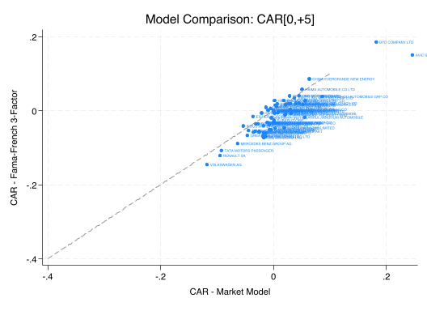

```
Section 8 tests passed
```

## Section 9: Event Study Visualizations

A classic event study plot shows the cumulative abnormal return over time around the event date. This visualization helps identify when the stock price reaction occurred and how it evolved.

### Task 9.1: Calculate Running CAR by Day

To create an event study plot, we need to calculate the cumulative abnormal return for each relative day. This shows how the CAR builds up over the event window.

[figure not shown]

Stata Tip

- `collapse (mean) ar_mm ar_ff, by(relday german)` — Calculate average AR by day and group
- `by german: gen car_running = sum(ar_mm)` — Calculate cumulative sum within each group

```
(Note: Below code run with echo to enable preserve/restore functionality.)

. preserve

. keep if relday >= -5 & relday <= 10
(47,201 observations deleted)

. collapse (mean) ar_mm ar_ff (semean) se_mm=ar_mm se_ff=ar_ff, by(relday germa
> n)

. sort german relday

. by german: gen car_running_mm = sum(ar_mm)

. by german: gen car_running_ff = sum(ar_ff)

. gen car_mm_upper = car_running_mm + 1.96 * se_mm

. gen car_mm_lower = car_running_mm - 1.96 * se_mm

. display "Running CAR by Day and Treatment Group (Market Model):"
Running CAR by Day and Treatment Group (Market Model):

. list relday german ar_mm car_running_mm if relday >= 0 & relday <= 5, noobs

  +-----------------------------------------+
  | relday   german       ar_mm   car_run~m |
  |-----------------------------------------|
  |      0        0    .0025936   -.0051629 |
  |      2        0    .0028018   -.0023611 |
  |      3        0    .0057771     .003416 |
  |      4        0   -.0008562    .0025598 |
  |      5        0   -.0003782    .0021816 |
  |-----------------------------------------|
  |      0        1    .0004172    .0250719 |
  |      2        1    -.056651   -.0315791 |
  |      3        1    .0220794   -.0094998 |
  |      4        1   -.0164794   -.0259792 |
  |      5        1   -.0081725   -.0341517 |
  +-----------------------------------------+

.
```

### Task 9.2: Create Event Study Plot

Create a classic event study plot showing the cumulative abnormal return over time, with separate lines for German and non-German automakers. Add a vertical line at t=0 to mark the event date.

```
(j = 0 1)

Data                               Long   ->   Wide
-----------------------------------------------------------------------------
Number of observations               26   ->   13
Number of variables                  10   ->   17
j variable (2 values)            german   ->   (dropped)
xij variables:
                                  ar_mm   ->   ar_mm0 ar_mm1
                                  ar_ff   ->   ar_ff0 ar_ff1
                         car_running_mm   ->   car_running_mm0 car_running_mm1
                         car_running_ff   ->   car_running_ff0 car_running_ff1
                                  se_mm   ->   se_mm0 se_mm1
                                  se_ff   ->   se_ff0 se_ff1
                           car_mm_upper   ->   car_mm_upper0 car_mm_upper1
                           car_mm_lower   ->   car_mm_lower0 car_mm_lower1
-----------------------------------------------------------------------------
file /Users/casparm4/Github/rsm-data-analytics-in-finance-private/private/assig
> nments/05-assignment/output/figures/event_study_mm.png written in PNG format
```

[figure not shown]

```
(Note: Below code run with echo to enable preserve/restore functionality.)

. twoway (line car_running_mm0 relday, lcolor(navy) lwidth(medium)) (line car_r
> unning_mm1 relday, lcolor(cranberry) lwidth(medium)) , xline(0, lpattern(dash
> ) lcolor(gray)) yline(0, lcolor(gray) lpattern(solid)) xtitle("Trading Days R
> elative to Event") ytitle("Cumulative Abnormal Return") title("Event Study: D
> ieselgate Announcement" "(Market Model)") legend(order(1 "Non-German Automake
> rs" 2 "German Automakers") position(6) rows(1)) xlabel(-5(1)10) scheme(s2colo
> r)

. graph export "$figures/event_study_mm.png", replace
file /Users/casparm4/Github/rsm-data-analytics-in-finance-private/private/assig
> nments/05-assignment/output/figures/event_study_mm.png written in PNG format

. restore

.
```

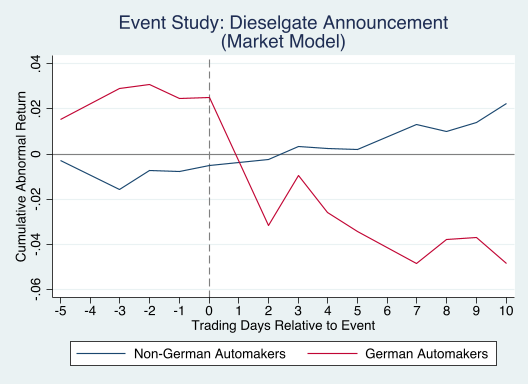

```
Section 9 tests passed
```

## Section 10: Cross-Sectional Analysis

Now we ask: **"Who was hit hardest?"** Cross-sectional analysis examines whether firm characteristics explain variation in CARs. We regress the CAR on firm attributes like German nationality, size, profitability, and leverage.

ℹ️ Background: Connecting to Assignment 03

In Assignment 03, you used **pre-calculated CARs** to run cross-sectional regressions. Now you understand where those CARs came from! You estimated the expected return models, calculated abnormal returns, and cumulated them over the event window.  
This cross-sectional regression tests whether the **German indicator** explains CARs after controlling for firm characteristics. A significant negative coefficient on `german` indicates that German firms experienced worse stock price reactions, even after accounting for size, profitability, and leverage.

### Task 10.1: Create Cross-Sectional Dataset

Collapse the panel data to one observation per firm, keeping the relevant variables: firm identifiers (`gvkey`, `conm`), treatment indicator (`german`), CARs (`car_mm`, `car_ff`), and firm characteristics (`log_at`, `roa`, `leverage`). Rename `log_at` to `size` for clearer interpretation.

```
(Note: Below code run with echo to enable preserve/restore functionality.)

. preserve

. by gvkey_num: keep if _n == 1
(48,125 observations deleted)

. keep gvkey conm german car_mm car_ff log_at roa leverage

. rename log_at size

. display "Cross-sectional dataset summary:"
Cross-sectional dataset summary:

. summarize car_mm car_ff german size roa leverage

    Variable |        Obs        Mean    Std. dev.       Min        Max
-------------+---------------------------------------------------------
      car_mm |         77    .0048181    .0489295    -.11785   .2460443
      car_ff |         77   -.0126132    .0499594  -.1457163   .1851212
      german |         77    .0519481    .2233774          0          1
        size |         77    10.46714    3.541051   3.388349   18.80747
         roa |         77    .0670423    .1045959  -.4132906   .3438476
-------------+---------------------------------------------------------
    leverage |         77    .2199779    .1982663          0   .9964587

.
```

### Task 10.2: Cross-Sectional Regression

Regress the CAR on firm characteristics: `german`, `size`, `roa`, and `leverage`. Run this regression for both the Market Model CAR and the Fama-French CAR. Use robust standard errors and create a formatted table comparing the results.

[figure not shown]

Stata Tip

- `regress car_mm german size roa leverage, robust` — OLS with robust standard errors
- `estimates store model_name` — Store results for later comparison
- `esttab` — Create formatted regression table

```
(Note: Below code run with echo to enable preserve/restore functionality.)

. regress car_mm german size roa leverage, robust

Linear regression                               Number of obs     =         77
                                                F(4, 72)          =       3.49
                                                Prob > F          =     0.0116
                                                R-squared         =     0.1032
                                                Root MSE          =      .0476

------------------------------------------------------------------------------
             |               Robust
      car_mm | Coefficient  std. err.      t    P>|t|     [95% conf. interval]
-------------+----------------------------------------------------------------
      german |  -.0671036   .0204224    -3.29   0.002    -.1078149   -.0263922
        size |  -.0012806   .0011073    -1.16   0.251     -.003488    .0009267
         roa |  -.0053264   .0511386    -0.10   0.917    -.1072693    .0966165
    leverage |  -.0017175   .0252879    -0.07   0.946     -.052128     .048693
       _cons |   .0224436   .0137891     1.63   0.108    -.0050444    .0499317
------------------------------------------------------------------------------

. estimates store cs_mm

. regress car_ff german size roa leverage, robust

Linear regression                               Number of obs     =         77
                                                F(4, 72)          =       5.22
                                                Prob > F          =     0.0009
                                                R-squared         =     0.1516
                                                Root MSE          =     .04728

------------------------------------------------------------------------------
             |               Robust
      car_ff | Coefficient  std. err.      t    P>|t|     [95% conf. interval]
-------------+----------------------------------------------------------------
      german |  -.0661513   .0226474    -2.92   0.005    -.1112981   -.0210044
        size |  -.0037847     .00116    -3.26   0.002    -.0060972   -.0014723
         roa |   .0369337   .0429735     0.86   0.393    -.0487324    .1225997
    leverage |  -.0007461   .0261314    -0.03   0.977    -.0528381    .0513458
       _cons |   .0281266   .0137899     2.04   0.045     .0006369    .0556163
```

[output cut: 28 more lines]

```
leverage                  -0.0017         -0.0007
                         (0.0253)        (0.0261)

Constant                   0.0224          0.0281**
                         (0.0138)        (0.0138)
----------------------------------------------------
Observations                   77              77
R-squared                   0.103           0.152
----------------------------------------------------
Standard errors in parentheses
* p<0.10, ** p<0.05, *** p<0.01

. restore

.
```

```
Section 10 tests passed
```

## Section 11: Statistical Tests

Beyond regression analysis, we conduct formal hypothesis tests to assess the statistical significance of our findings. We test two key hypotheses about the CARs.

ℹ️ Background: Two Key Statistical Tests

We test two hypotheses:  
**Test 1: Is the CAR different from zero?**

- H<sub>0</sub>: CAR = 0 (no abnormal return)
- H<sub>A</sub>: CAR ≠ 0 (significant stock price reaction)
- Use a one-sample t-test for each group (German and non-German)

**Test 2: Do German and non-German firms differ?**

- H<sub>0</sub>: CAR<sub>German</sub> = CAR<sub>Non-German</sub>
- H<sub>A</sub>: CAR<sub>German</sub> ≠ CAR<sub>Non-German</sub>
- Use a two-sample t-test comparing groups

### Task 11.1: Test if CAR Differs from Zero

Test whether the average CAR is statistically different from zero for each group (German and non-German automakers). Run this test for both the Market Model and Fama-French CARs.

[figure not shown]

Stata Tip

Use `ttest car_mm == 0 if german == 1` to test if the mean CAR equals zero for German firms.

```
(Note: Below code run with echo to enable preserve/restore functionality.)

. preserve

. by gvkey_num: keep if _n == 1
(48,125 observations deleted)

. display "Test: CAR(MM) = 0 for German firms"
Test: CAR(MM) = 0 for German firms

. display "=================================="
==================================

. ttest car_mm == 0 if german == 1

One-sample t test
------------------------------------------------------------------------------
Variable |     Obs        Mean    Std. err.   Std. dev.   [95% conf. interval]
---------+--------------------------------------------------------------------
  car_mm |       4   -.0588063    .0216415     .043283   -.1276793    .0100666
------------------------------------------------------------------------------
    mean = mean(car_mm)                                           t =  -2.7173
H0: mean = 0                                     Degrees of freedom =        3

    Ha: mean < 0                 Ha: mean != 0                 Ha: mean > 0
 Pr(T < t) = 0.0364         Pr(|T| > |t|) = 0.0727          Pr(T > t) = 0.9636

. display _newline "Test: CAR(MM) = 0 for Non-German firms"

Test: CAR(MM) = 0 for Non-German firms

. display "======================================"
======================================

. ttest car_mm == 0 if german == 0

One-sample t test
------------------------------------------------------------------------------
Variable |     Obs        Mean    Std. err.   Std. dev.   [95% conf. interval]
---------+--------------------------------------------------------------------
```

[output cut: 38 more lines]

```
One-sample t test
------------------------------------------------------------------------------
Variable |     Obs        Mean    Std. err.   Std. dev.   [95% conf. interval]
---------+--------------------------------------------------------------------
  car_ff |      73   -.0092418     .005576    .0476415   -.0203574    .0018737
------------------------------------------------------------------------------
    mean = mean(car_ff)                                           t =  -1.6574
H0: mean = 0                                     Degrees of freedom =       72

    Ha: mean < 0                 Ha: mean != 0                 Ha: mean > 0
 Pr(T < t) = 0.0509         Pr(|T| > |t|) = 0.1018          Pr(T > t) = 0.9491

. restore

.
```

### Task 11.2: Test Difference Between Groups

Test whether German automakers have significantly different CARs than non-German automakers. This two-sample t-test directly compares the treatment and control groups.

```
(Note: Below code run with echo to enable preserve/restore functionality.)

. preserve

. by gvkey_num: keep if _n == 1
(48,125 observations deleted)

. display "Test: CAR(MM) German vs Non-German"
Test: CAR(MM) German vs Non-German

. display "=================================="
==================================

. ttest car_mm, by(german)

Two-sample t test with equal variances
------------------------------------------------------------------------------
   Group |     Obs        Mean    Std. err.   Std. dev.   [95% conf. interval]
---------+--------------------------------------------------------------------
       0 |      73    .0083044    .0055045    .0470301   -.0026685    .0192773
       1 |       4   -.0588063    .0216415     .043283   -.1276793    .0100666
---------+--------------------------------------------------------------------
Combined |      77    .0048181     .005576    .0489295   -.0062875    .0159238
---------+--------------------------------------------------------------------
    diff |            .0671108    .0240767                .0191475     .115074
------------------------------------------------------------------------------
    diff = mean(0) - mean(1)                                      t =   2.7874
H0: diff = 0                                     Degrees of freedom =       75

    Ha: diff < 0                 Ha: diff != 0                 Ha: diff > 0
 Pr(T < t) = 0.9966         Pr(|T| > |t|) = 0.0067          Pr(T > t) = 0.0034

. display _newline "Test: CAR(FF) German vs Non-German"

Test: CAR(FF) German vs Non-German

. display "=================================="
==================================

. ttest car_ff, by(german)

Two-sample t test with equal variances
------------------------------------------------------------------------------
   Group |     Obs        Mean    Std. err.   Std. dev.   [95% conf. interval]
---------+--------------------------------------------------------------------
       0 |      73   -.0092418     .005576    .0476415   -.0203574    .0018737
       1 |       4   -.0741406    .0292969    .0585938   -.1673765    .0190952
---------+--------------------------------------------------------------------
Combined |      77   -.0126132    .0056934    .0499594   -.0239526   -.0012738
---------+--------------------------------------------------------------------
    diff |            .0648988    .0247142                .0156655     .114132
------------------------------------------------------------------------------
    diff = mean(0) - mean(1)                                      t =   2.6260
H0: diff = 0                                     Degrees of freedom =       75

    Ha: diff < 0                 Ha: diff != 0                 Ha: diff > 0
 Pr(T < t) = 0.9948         Pr(|T| > |t|) = 0.0105          Pr(T > t) = 0.0052

. restore

.
```

```
Section 11 tests passed
```

## Section 12: Interpretation

In this final analytical section, you will synthesize your findings and provide economic interpretation of the event study results.

### Task 12.1: Written Analysis

Based on your event study results, write a comprehensive interpretation addressing the following questions:

📝 Task

Write a 2-3 paragraph analysis addressing:

1. **Main Finding**: What was the magnitude and statistical significance of the stock market reaction for German automakers versus non-German peers? Was this difference economically meaningful?
2. **Model Comparison**: Do the Market Model and Fama-French 3-Factor Model yield similar conclusions? Why might they differ (or agree)?
3. **Economic Magnitude**: If you were to translate the CAR into dollar value destroyed (e.g., for VW with a market cap of approximately EUR 70 billion pre-event), what would be the estimated shareholder wealth destruction?
4. **Cross-Sectional Variation**: Did all German automakers react similarly, or was there heterogeneity? What might explain any differences?
5. **Limitations**: What are the key limitations of this analysis? Consider: single event, small sample size, model assumptions, potential confounding events during the event window.

**Main Finding and Economic Significance**

**Model Comparison**

**Economic Magnitude and Limitations**

## Section 13: Export Results

In this section, you will export your regression results to publication-quality tables that can be included in research reports or academic papers.

### Task 13.1: Export Cross-Sectional Regression Table

Export the cross-sectional regression results to a LaTeX table file. This table should include both the Market Model and Fama-French 3-Factor Model results for easy comparison.

[figure not shown]

Stata Tip

Use `esttab` with the `using` option to export to a file. Key options:

- `replace` — Overwrite existing file
- `se` — Show standard errors instead of t-statistics
- `star(* 0.10 ** 0.05 *** 0.01)` — Significance stars
- `label` — Use variable labels
- `title()` — Add table title

```
(Note: Below code run with echo to enable preserve/restore functionality.)

. preserve

. by gvkey_num: keep if _n == 1
(48,125 observations deleted)

. label variable german "German Automaker"

. label variable car_mm "CAR (Market Model)"

. label variable car_ff "CAR (Fama-French)"

. eststo cs_mm: regress car_mm german, robust

Linear regression                               Number of obs     =         77
                                                F(1, 75)          =      11.51
                                                Prob > F          =     0.0011
                                                R-squared         =     0.0939
                                                Root MSE          =     .04689

------------------------------------------------------------------------------
             |               Robust
      car_mm | Coefficient  std. err.      t    P>|t|     [95% conf. interval]
-------------+----------------------------------------------------------------
      german |  -.0671108   .0197817    -3.39   0.001    -.1065179   -.0277036
       _cons |   .0083044    .005539     1.50   0.138    -.0027299    .0193387
------------------------------------------------------------------------------

. eststo cs_ff: regress car_ff german, robust

Linear regression                               Number of obs     =         77
                                                F(1, 75)          =       6.08
                                                Prob > F          =     0.0159
                                                R-squared         =     0.0842
                                                Root MSE          =     .04813

------------------------------------------------------------------------------
             |               Robust
      car_ff | Coefficient  std. err.      t    P>|t|     [95% conf. interval]
```

[output cut: 10 more lines]

```
> %9.4f) se(%9.4f) stats(N r2, labels("Observations" "R-squared") fmt(%9.0f %9.
> 3f))
(output written to /Users/casparm4/Github/rsm-data-analytics-in-finance-private
> /private/assignments/05-assignment/output/tables/car_crosssection_regression.
> tex)

. display "✅ Regression table exported to $tables/car_crosssection_regression.t
> ex"
✅ Regression table exported to /Users/casparm4/Github/rsm-data-analytics-in-fin
> ance-private/private/assignments/05-assignment/output/tables/car_crosssection
> _regression.tex

. restore

.
```

```
✅ Section 13 tests passed
```

## References

- MacKinlay, A.C. (1997). Event Studies in Economics and Finance. *Journal of Economic Literature*, 35(1), 13-39.
- Fama, E.F. & French, K.R. (1993). Common Risk Factors in the Returns on Stocks and Bonds. *Journal of Financial Economics*, 33(1), 3-56.
- [The Effect: An Introduction to Research Design and Causality](https://theeffectbook.net/) — Huntington-Klein, N.
- [Stata Documentation](https://www.stata.com/features/documentation/)
- [Kenneth French Data Library](https://mba.tuck.dartmouth.edu/pages/faculty/ken.french/data_library.html) — Source for Fama-French factors

Data Analytics for Finance

BM17FI · Academic Year 2025–26

[figure not shown]

Created by: Caspar David Peter

© 2026 Rotterdam School of Management